# Extra Credit 2

Ryan Hensley

2023-09-29

**Copyright Kaitlyn Hoffmann, All rights reserved. Not for resale, distribution, or posting to external sites for all content provided.**

## Question 1: Load in the data house.csv as a data frame object called house

```r
house = read.csv("house.csv")
```

## Question 2: Display the first 5 rows of the data frame object house

```r
head(house,5)
```

```
##    value lotsize bedroom bathroom room age    tax location       style     CAC
## 1 387.00    6.00       2      2.0    7  30 5140.8        A       ranch present
## 2 485.82   10.00       4      2.0    8  28 8100.0        B       ranch present
## 3 378.00   10.00       3      1.5    7  30 7074.0        B split level present
## 4 444.60    8.00       4      2.0    8  30 5580.0        A        cape present
## 5 539.82    5.18       4      3.5    8  15 8571.6        A    colonial present
##   fireplace basement         garage
## 1    absent      yes one-car garage
## 2    absent      yes two-car garage
## 3    absent      yes one-car garage
## 4   present      yes one-car garage
## 5    absent      yes two-car garage
```

## Question 3: Display the last 5 rows of the data frame object house

```r
tail(house,5)
```

```
##      value lotsize bedroom bathroom room age     tax location       style
## 358 323.73   12.80       3      1.0    6  27  6139.8        E       ranch
## 359 323.82   22.50       4      1.0    8  25  8508.6        E       ranch
## 360 328.50   13.35       4      2.5    9  19  6638.4        E    colonial
## 361 351.00   13.35       4      2.5    8  20 10065.6        E split level
## 362 378.00   18.75       6      2.5   10   4  9205.2        E    colonial
##        CAC fireplace basement         garage
## 358 absent    absent       no one-car garage
## 359 absent   present      yes two-car garage
## 360 absent    absent       no one-car garage
## 361 absent   present      yes two-car garage
## 362 absent   present      yes two-car garage
```

## Question 4: Display the structure of the data frame house; look at the data types and make sure they are loaded appropriately

```r
str(house)
```

```
## 'data.frame':    362 obs. of  13 variables:
##  $ value    : num  387 486 378 445 540 ...
##  $ lotsize  : num  6 10 10 8 5.18 ...
##  $ bedroom  : int  2 4 3 4 4 4 3 4 3 3 ...
##  $ bathroom : num  2 2 1.5 2 3.5 2 1.5 2.5 1 2 ...
##  $ room     : int  7 8 7 8 8 8 7 8 7 9 ...
##  $ age      : int  30 28 30 30 15 34 30 16 26 46 ...
##  $ tax      : num  5141 8100 7074 5580 8572 ...
##  $ location : chr  "A" "B" "B" "A" ...
##  $ style    : chr  "ranch" "ranch" "split level" "cape" ...
##  $ CAC      : chr  "present" "present" "present" "present" ...
##  $ fireplace: chr  "absent" "absent" "absent" "present" ...
##  $ basement : chr  "yes" "yes" "yes" "yes" ...
##  $ garage   : chr  "one-car garage" "two-car garage" "one-car garage" "one-car garage" ...
```

## Question 5: Display the total number of rows and columns in the data frame house

- what does the number of rows represent (conceptually)? Look at the data, see what each row represents. Comment your response using # within the chunk.

```r
#number of rows (code)
nrow(house)
```

```
## [1] 362
```

```r
#number of columns (code)
ncol(house)
```

```
## [1] 13
```

```r
# what does the number of rows represent (conceptually)?
#Rows are equal to the number of houses
```

**ADD THE QUESTIONS BELOW AND A CHUNK FOLLOWING EACH TO THE EC2** ## Question 6: Basic calculations: - What is the average lotsize from house? - What is the average bedroom from house? - What are the max tax from house? - What is the spread/standard deviation (variation) tax from house? - What is the range for tax from house?

```r
mean(house$lotsize)
```

```
## [1] 9.326823
```

```r
mean(house$bedroom)
```

```
## [1] 3.574586
```

```r
max(house$tax)
```

```
## [1] 11646
```

```r
sd(house$tax)
```

```
## [1] 1602.784
```

```r
max(house$tax)-min(house$tax)
```

```
## [1] 9846
```

## Question 7: Display the summary results for the data frame called house

```r
summary(house)
```

```
##      value          lotsize          bedroom         bathroom
##  Min.   :180.0   Min.   : 3.550   Min.   :1.000   Min.   :1.00
##  1st Qu.:279.0   1st Qu.: 6.000   1st Qu.:3.000   1st Qu.:1.00
##  Median :315.0   Median : 7.500   Median :3.000   Median :1.50
##  Mean   :320.1   Mean   : 9.327   Mean   :3.575   Mean   :1.61
##  3rd Qu.:342.0   3rd Qu.:10.000   3rd Qu.:4.000   3rd Qu.:2.00
##  Max.   :558.0   Max.   :37.500   Max.   :7.000   Max.   :3.50
##       room             age             tax          location
##  Min.   : 4.000   Min.   : 1.00   Min.   : 1800   Length:362
##  1st Qu.: 6.000   1st Qu.:28.00   1st Qu.: 5040   Class :character
##  Median : 7.000   Median :33.50   Median : 5940   Mode  :character
##  Mean   : 7.052   Mean   :33.43   Mean   : 6104
##  3rd Qu.: 8.000   3rd Qu.:37.00   3rd Qu.: 7148
##  Max.   :12.000   Max.   :95.00   Max.   :11646
##     style               CAC             fireplace           basement
##  Length:362         Length:362         Length:362         Length:362
##  Class :character   Class :character   Class :character   Class :character
##  Mode  :character   Mode  :character   Mode  :character   Mode  :character
##
##
##
##     garage
##  Length:362
##  Class :character
##  Mode  :character
##
##
##
```

## Question 8: Display the summary results for each (BY) location separately for column 1 (value) only (points off if notcorrect view)

- Analyze the results
- Which location has the highest value on average (mean)? Comment your response using # within the chunk.
- Which location has the lowest value on average (mean)? Comment your response using # within the chunk.

```r
by(house[,1],house$location,summary)
```

```
## house$location: A
##    Min. 1st Qu.  Median    Mean 3rd Qu.    Max.
##   279.0   334.8   375.0   387.4   414.0   558.0
## ------------------------------------------------------------
## house$location: B
##    Min. 1st Qu.  Median    Mean 3rd Qu.    Max.
##   180.0   322.7   335.2   344.4   359.8   549.0
## ------------------------------------------------------------
## house$location: C
##    Min. 1st Qu.  Median    Mean 3rd Qu.    Max.
##   252.0   288.0   306.0   310.2   324.0   431.8
## ------------------------------------------------------------
## house$location: D
##    Min. 1st Qu.  Median    Mean 3rd Qu.    Max.
##   198.0   250.2   266.4   278.7   288.9   449.8
## ------------------------------------------------------------
## house$location: E
##    Min. 1st Qu.  Median    Mean 3rd Qu.    Max.
##   198.0   252.0   277.2   276.3   300.6   378.0
```

```r
#houseA
#houseE
```

## Question 9: Display a frequency table for style from the data frame house

- How many split level style houses? Comment your response using # within the chunk.

```r
table(house$style)
```

```
##
##           cape       colonial expanded ranch          ranch    split level
##            112             47             38            119             46
```

```r
#46
```

## Question 10: Display a table summarizing the Average (mean) tax by style from the data frame house

```r
tapply(house$tax,house$style,mean)
```

```
##           cape       colonial expanded ranch          ranch    split level
##       5178.391       7024.328       6893.147       6004.830       7019.139
```

## Question 11: Display/Plot the distribution for the value using the data frame house (histogram)

- add a color col=“red”
- add a title main = “House Value Distribution Table”

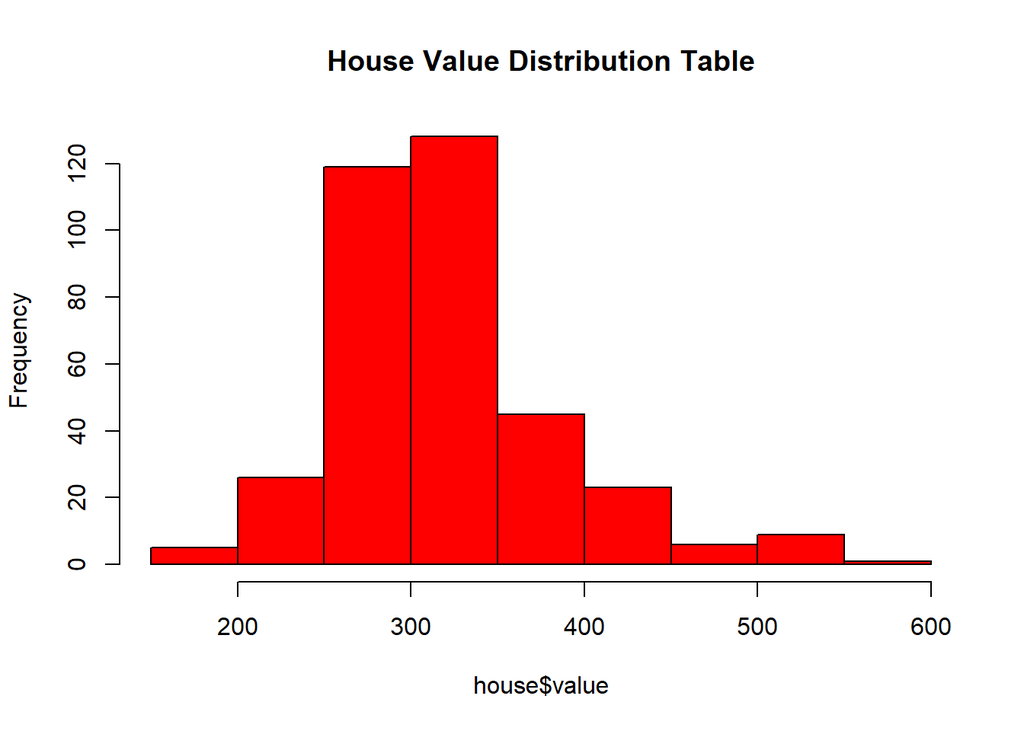

```r
hist(house$value,main = "House Value Distribution Table",col = "red")
```

## Question 12: Display a boxplot for value from the data frame house

- add a color col = “limegreen”
- add a title main = “House Value Distribution”

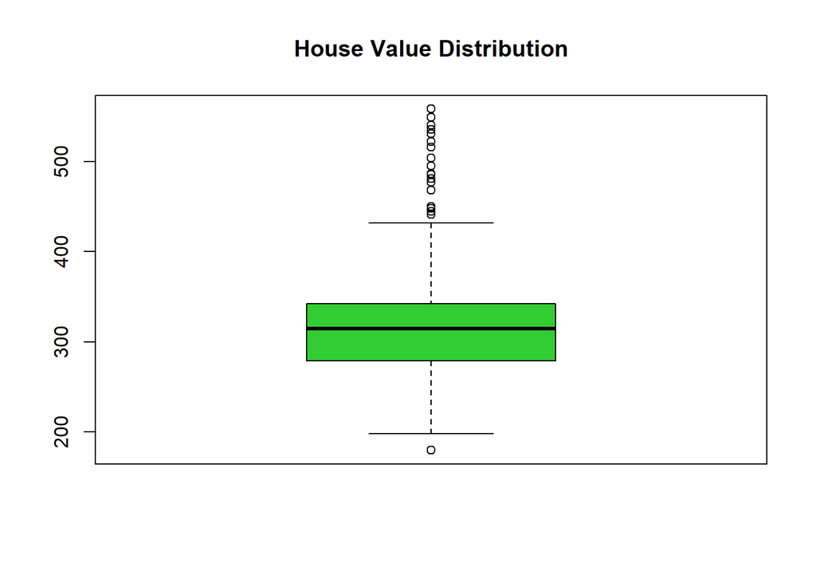

```r
boxplot(house$value,main = "House Value Distribution",col = "limegreen")
```

## Question 13: Display a boxplot for value by location from the data frame house

- add a color col = “yellowgreen”
- add a title main = “House Value Distribution by Location”

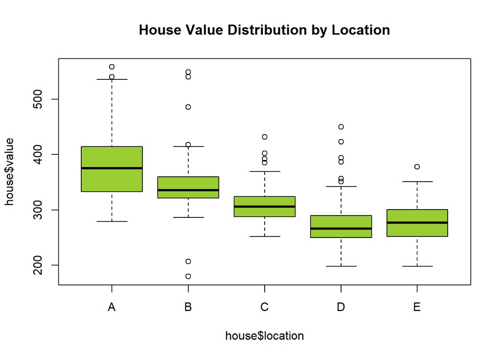

```r
boxplot(house$value~house$location,main = "House Value Distribution by Location", col = "yellowgreen")
```

### Knit to HTML

**Copyright Kaitlyn Hoffmann, All rights reserved. Not for resale, distribution, or posting to external sites for all content provided.**